# E2. Preparación y Modelado de los datos

12 de Mayo del 2022

- Equipo 3
  - Ximena Martínez A00829670
  - Chantal Aimeé Simó A00827554
  - Carolina Velarde A01720509
  - Kízari Hernández A00828451

## Fraud Detection System

### Sistema de detección de fraude y puntuación de riesgo

- Insights de la industria financiera
  - El 47% de las compañías informaron haber experimentado fraude en los últimos dos años (Segundo nivel más alto reportado en 20 años). *Encuesta Mundial sobre Fraude y Delitos Económicos de PwC, 2020*
  - Las entidades financieras que sufrieron fraude reportaron pérdidas de más de US$ 50 millones. *Encuesta Mundial sobre Fraude y Delitos Económicos de PwC, 2020*
  - Desde el 2021 el fraude financiero ha incrementado 52% en México. *Forbes México, 2022*

Para la parte de datos estructurados, aplicando técnicas de aprendizaje automático con modelos supervisados, nosotras proponemos un sistema de detección de fraude en donde se examinarán todos los datos pertinentes relativos a una transacción y se asignara una puntuación de riesgo a la misma. En base a la puntuación de riesgo, el sistema recomendará permitir la transacción, bloquearla o solicitar una autenticación avanzada antes de permitirla.

#### Valor agregado de nuestra propuesta

**Personalización**: Analiza la actividad “normal” del cliente, por lo que cuando detecta una anomalía, puede bloquear o marcar automáticamente un pago para que lo revise un analista ante la situación de fraude.

**Precisión**: El ML aprende de patrones de comportamiento normal. Son muy rápidos para adaptarse a los cambios en ese comportamiento normal y pueden identificar rápidamente patrones de transacciones fraudulentas.

**Eficiencia**: El ML hace todo el trabajo sucio del análisis de datos en una fracción del tiempo que les tomaría incluso a 100 analistas de fraude. Esto ayuda al ahorro de gastos en revisiones manuales y perdidas de dinero en fraude.

**Confianza**: Colabora en el desafío de equilibrar los requisitos de cumplimiento, con la necesidad de proteger a los clientes contra las amenazas del fraude, sin comprometer la experiencia general del cliente.

### Limpieza de los datos

Limpieza general de las tres bases de datos: *Demographic Dataset*, *Transaction History Dataset* y *Shopping Devices*.

#### **1. Demographic Dataset**

La base de datos “Demographic Data” contiene datos demográficos como son el número de tarjeta de crédito del cliente, el comerciante, la categoría del comerciante, el amount de la transacción, los nombres del cliente, el género, la calle, cuidad, estado y código postal en donde el cliente realizó la transacción, la latitud, longitud y la población de la ciudad, en qué trabaja el cliente, su fecha de nacimiento, también tenemos el número de la transacción, la fecha y horario en el que se realizó la transacción y por último tenemos si es o no fraudulenta la transacción.

```r
# Train y Test
test <- read_csv('fraudTest.csv')
train <- read_csv('fraudTrain.csv')
```

Antes de unir el ‘Train’ y ‘Test’ para nuestro análisis, verificamos que los tipos de datos en ambas bases sean iguales para poder hacer la unión.

```r
# Verificar que los tipos de datos sean iguales para la unión del 'Test' y 'Train'
janitor::compare_df_cols_same(train, test)
```

```
## [1] TRUE
```

```r
janitor::compare_df_cols(train, test)
```

```
##              column_name           train            test
## 1                   ...1         numeric         numeric
## 2                    amt         numeric         numeric
## 3               category       character       character
## 4                 cc_num         numeric         numeric
## 5                   city       character       character
## 6               city_pop         numeric         numeric
## 7                    dob            Date            Date
## 8                  first       character       character
## 9                 gender       character       character
## 10              is_fraud         numeric         numeric
## 11                   job       character       character
## 12                  last       character       character
## 13                   lat         numeric         numeric
## 14                  long         numeric         numeric
## 15             merch_lat         numeric         numeric
## 16            merch_long         numeric         numeric
## 17              merchant       character       character
## 18                 state       character       character
## 19                street       character       character
## 20 trans_date_trans_time POSIXct, POSIXt POSIXct, POSIXt
## 21             trans_num       character       character
## 22             unix_time         numeric         numeric
## 23                   zip         numeric         numeric
```

##### Unión de base de datos y balanceo

Ya verificado el tipo de dato podemos continuar con la unión del ‘Train’ y ‘Test’ para nuestra limpieza y análisis. También haremos una copia para hacer las queries con la data original y no balanceada

```r
# Unión de 'Test' y 'Train'
DemographicData <- bind_rows(train,test)
DemographicDataQueries <- bind_rows(train,test)
table(DemographicData$is_fraud)
```

```
##
##       0       1
## 1842743    9651
```

```r
# Balanceo de los datos
DemographicData <- ROSE::ovun.sample(is_fraud ~ ., data = train,
                               method = "both", p=0.5, N=15000,
                               seed = 1)$data
table(DemographicData$is_fraud)
```

```
##
##    0    1
## 7548 7452
```

```r
table(train$is_fraud)
```

```
##
##       0       1
## 1289169    7506
```

##### Changing data type to Factor

Primero cambiamos el tipo de dato, se cambió todo lo que era ‘Character’ a ‘Factor’ utilizando sapply y lapply, de esta manera se puede cambiar todo en una sola línea de código sin tener que ir columna por columna.

```r
# Cambiar el tipo de dato 'character' a 'factor'
DemographicData[sapply(DemographicData, is.character)] <- lapply(DemographicData[sapply(DemographicData, is.character)], as.factor)
#skim(DemographicData)
```

##### Eliminating variables

Después, eliminamos las columnas que no son tan relaventes y no utilizaremos para nuestro análisis.

```r
# Eliminar columnas que no se van a utilizar
#colnames(DemographicData)
DemographicData %<>% select(-"...1", -cc_num, -dob, -trans_num, -unix_time, -merch_lat, -merch_long)
#colnames(DemographicData)
```

##### Changing data type to Date Time

Ahora, algo muy importante en esta base de datos es la fecha y hora en la que se realizó la transacción. Pero nos enfocaremos más en la hora que en la fecha ya que solo tenemos datos de 2019 y 2020.

Para este arreglo, lo que hacemos es cambiar el formato de la columna ‘trans_date_trans_time’ para que en lugar de que sea ‘2019-01-01 00:00:18 tengamos una nueva columna de ’Hour’ en donde solo tengamos la hora, sin los minutos y segundos ya que no todas las fechas tienen bien el formato de 00:00:00, en algunas está como 1:00:00 y es más difícil trabajar con eso.

```r
# Arreglo de las fechas
DemographicData$trans_date_trans_time <- strptime(DemographicData$trans_date_trans_time, format = "%Y-%m-%d %H:%M:%OS")

DemographicData$Hour <- format(DemographicData$trans_date_trans_time, "%H")
```

Como ya se arregló y se creó una columna nueva para el tiempo, eliminamos la columna original ya que no la estaremos utilizando en el análisis.

```r
# Eliminar columna de fechas (original) para dejar unicamente la nueva columna agregada
DemographicData %<>% select(-trans_date_trans_time)
```

##### Feature Engineering

En esta parte, se decidió crear una nueva columna ‘Schedule’ en donde, en lugar de horas establecimos rangos para que de la hora 00 hasta las 05 sea Madrugada, de las 06 a las 11 sea Mañana, de las 12 a las 17 sea Tarde y por último, que de las 18 a las 23 sea Noche.

```r
# Determinar rangos para nueva columna de horario
DemographicData %<>%
  mutate(Schedule = fct_collapse(DemographicData$Hour,
                         Madrugada =  c("00", "01", "02", "03", "04", "05"),
                         Mañana = c("06", "07", "08", "09", "10", "11"),
                         Tarde = c("12", "13", "14", "15", "16", "17"),
                         Noche = c("18", "19", "20", "21", "22", "23")))
```

Ahora, vamos a arreglar la columna ‘Merchant’ eliminando la palabra fraud_ ya que en esta columna nos aparece: fraud_Rippin, Kub and Mann y decidimos mejor solo dejar al comerciante sin que se anteponga la palabra fraud.

```r
# Arreglar la columna de merchant eliminando la palabra fraud_
DemographicData <- DemographicData %>%
  mutate(Merchant = str_remove(merchant, "fraud_"))
DemographicData %<>% select(-merchant)
```

Por último, lo que estamos haciendo en esta parte es cambiar ligeramente los nombres de las columnas para que empiezen con mayúsculas y nombres cortos.

```r
# Arreglar los títulos de todas las columnas
names(DemographicData) = c("Category", "Amount", "First", "Last", "Gender", "Street", "City", "State", "Zip", "Lat", "Long", "City_Population", "Job", "Is_Fraud", "Hour", "Schedule", "Merchant")
#names(DemographicData)
```

**Ya con esto podemos ver que todas las variables estan limpias y en su tipo correcto.**

```r
glimpse(DemographicData)
```

```
## Rows: 15,000
## Columns: 17
## $ Category        <fct> gas_transport, entertainment, shopping_net, entertainm…
## $ Amount          <dbl> 65.32, 26.94, 3.43, 20.06, 18.39, 258.13, 23.31, 205.3…
## $ First           <fct> Hayden, Melissa, Ann, Kevin, Brooke, Mary, Donna, Jenn…
## $ Last            <fct> Sanders, Meza, Lawson, Elliott, Fisher, Wall, Moreno, …
## $ Gender          <fct> M, F, F, M, F, F, F, F, F, F, M, F, M, F, F, F, M, F, …
## $ Street          <fct> 8465 Reed Green Suite 559, 244 Abbott Parkway, 144 Eva…
## $ City            <fct> Montandon, Loxahatchee, Burbank, Newark Valley, San An…
## $ State           <fct> PA, FL, WA, NY, TX, NJ, WV, OH, CA, NC, NE, GA, OH, LA…
## $ Zip             <dbl> 17850, 33470, 99323, 13811, 76905, 7060, 24970, 43102,…
## $ Lat             <dbl> 40.9661, 26.7383, 46.1966, 42.2281, 31.4647, 40.6152, …
## $ Long            <dbl> -76.8575, -80.2760, -118.9017, -76.1625, -100.3900, -7…
## $ City_Population <dbl> 645, 26551, 3684, 4354, 103927, 71485, 4575, 4512, 940…
## $ Job             <fct> "Orthoptist", "Paramedic", "Musician", "Further educat…
## $ Is_Fraud        <dbl> 0, 0, 0, 0, 0, 0, 0, 0, 0, 0, 0, 0, 0, 0, 0, 0, 0, 0, …
## $ Hour            <chr> "00", "15", "22", "18", "01", "03", "21", "19", "19", …
## $ Schedule        <fct> Madrugada, Tarde, Noche, Noche, Madrugada, Madrugada, …
## $ Merchant        <chr> "Erdman-Kertzmann", "Fadel, Mertz and Rippin", "Lemke-…
```

##### Corrplots

Primero, para esta base de datos, convertimos la variable de Is_Fraud a factor y sacamos todas las variables que son factor para únicamente trabajar con ellas en los corrplots.

```r
# Convertimos a factor la variable Is_Fraud
DemographicData$Is_Fraud <- as.factor(DemographicData$Is_Fraud)
# Sacamos todas las varibles tipo factor.
data_fact_demo <- DemographicData[,unlist(lapply(DemographicData, is.factor))]
```

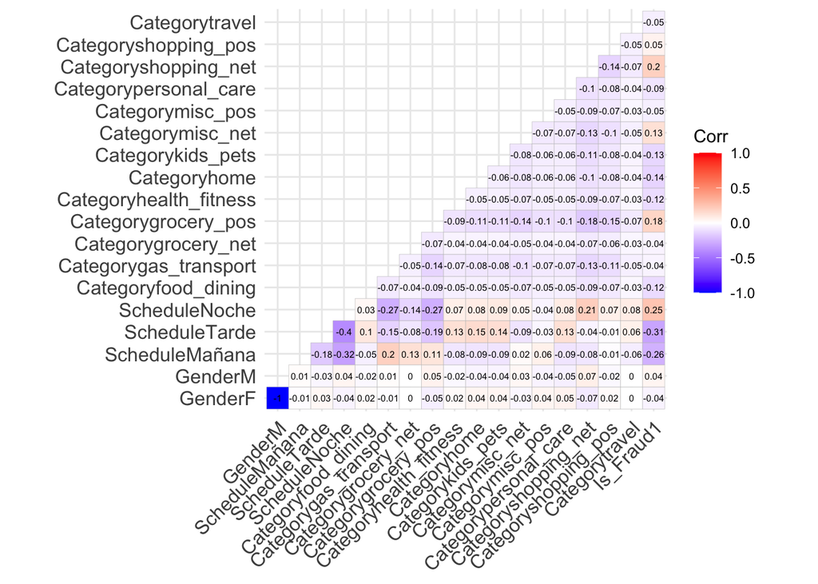

```r
# Corrplot 1
data_fact1 <- data_fact_demo %>% select(Gender,Schedule, Category, Is_Fraud)
model.matrix(~0+., data=data_fact1) %>%
   cor(use="pairwise.complete.obs") %>%
   ggcorrplot::ggcorrplot(show.diag = F, type="lower", lab=TRUE, lab_size=2)
```

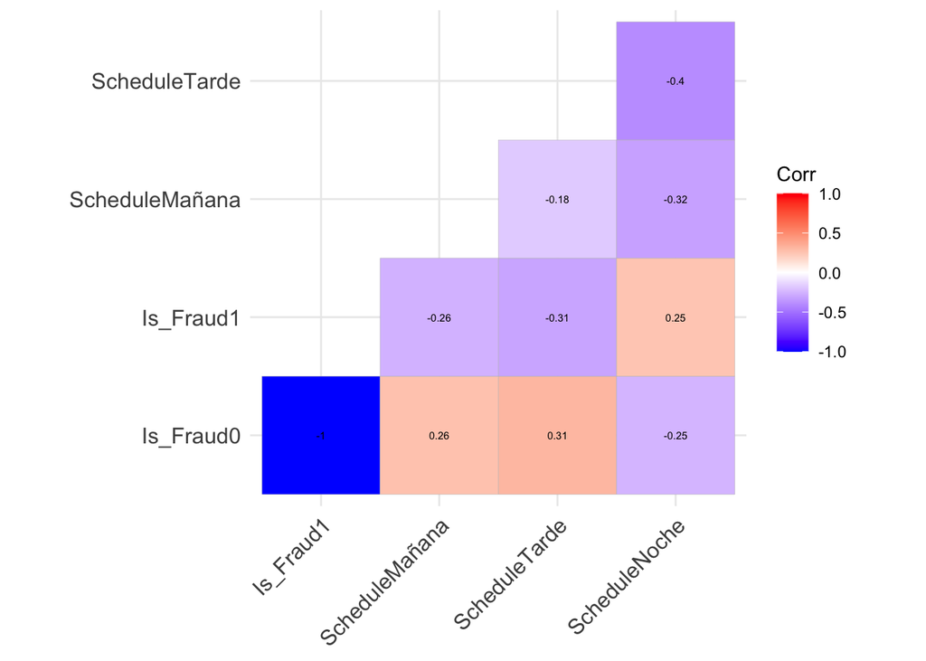

```r
# Corrplot 2
data_fact2 <- data_fact_demo %>% select(Is_Fraud, Schedule)
model.matrix(~0+., data=data_fact2) %>%
  cor(use="pairwise.complete.obs") %>%
  ggcorrplot::ggcorrplot(show.diag = F, type="lower", lab=TRUE, lab_size=2)
```

Al ver estas tablas de correlación, podemos ver que las variables en general no presentan una correlación significativa entre ellas. En cierta forma esto es bueno ya que nos indica que no hay multicolinealidad.

##### Count of levels and it comparison

Para nuestra análisis exploratorio realizamos una cuenta comparativa de nuestra base de datos original y de nuestra base de datos filtrada por las personas que sufrieron fraude.

**Fraud**

Contamos con 1,842,743 (99%) personas sin fraude y 9,651 (0.52%) que si sufrieron fraude

```r
prop.table(table(DemographicDataQueries$is_fraud))
```

```
##
##           0           1
## 0.994789985 0.005210015
```

```r
DemographicDataFraud <- DemographicDataQueries %>% filter(is_fraud == 1)
```

**Gender**

```r
DemographicDataQueries %>% count(gender,sort = TRUE)
```

```
## # A tibble: 2 × 2
##   gender       n
##   <chr>    <int>
## 1 F      1014749
## 2 M       837645
```

```r
DemographicDataFraud %>% count(gender,sort = TRUE)
```

```
## # A tibble: 2 × 2
##   gender     n
##   <chr>  <int>
## 1 F       4899
## 2 M       4752
```

**Category**

Para esta variable contamos con 14 niveles donde vemos que de cada una tienen una proporción grande de las personas que sufrieron fraude y de las que no.

```r
DemographicDataQueries %>% count(category, sort = TRUE)
```

```
## # A tibble: 14 × 2
##    category            n
##    <chr>           <int>
##  1 gas_transport  188029
##  2 grocery_pos    176191
##  3 home           175460
##  4 shopping_pos   166463
##  5 kids_pets      161727
##  6 shopping_net   139322
##  7 entertainment  134118
##  8 food_dining    130729
##  9 personal_care  130085
## 10 health_fitness 122553
## 11 misc_pos       114229
## 12 misc_net        90654
## 13 grocery_net     64878
## 14 travel          57956
```

```r
DemographicDataFraud %>% count(category, sort = TRUE)
```

```
## # A tibble: 14 × 2
##    category           n
##    <chr>          <int>
##  1 grocery_pos     2228
##  2 shopping_net    2219
##  3 misc_net        1182
##  4 shopping_pos    1056
##  5 gas_transport    772
##  6 misc_pos         322
##  7 kids_pets        304
##  8 entertainment    292
##  9 personal_care    290
## 10 home             265
## 11 food_dining      205
## 12 health_fitness   185
## 13 grocery_net      175
## 14 travel           156
```

**Merchant**

Para esta variable contamos con 693 niveles donde vemos que de cada una tienen una proporción grande de las personas que sufrieron fraude y de las que no.

```r
DemographicDataQueries %>% count(merchant, sort = TRUE)
```

```
## # A tibble: 693 × 2
##    merchant                  n
##    <chr>                 <int>
##  1 fraud_Kilback LLC      6262
##  2 fraud_Cormier LLC      5246
##  3 fraud_Schumm PLC       5195
##  4 fraud_Kuhn LLC         5031
##  5 fraud_Boyer PLC        4999
##  6 fraud_Dickinson Ltd    4953
##  7 fraud_Emard Inc        3867
##  8 fraud_Cummerata-Jones  3860
##  9 fraud_Corwin-Collins   3853
## 10 fraud_Rodriguez Group  3843
## # … with 683 more rows
```

```r
DemographicDataFraud %>% count(merchant, sort = TRUE)
```

```
## # A tibble: 685 × 2
##    merchant                 n
##    <chr>                <int>
##  1 fraud_Kilback LLC       62
##  2 fraud_Kozey-Boehm       60
##  3 fraud_Rau and Sons      60
##  4 fraud_Doyle Ltd         57
##  5 fraud_Terry-Huel        56
##  6 fraud_Boyer PLC         55
##  7 fraud_Kuhn LLC          55
##  8 fraud_Cormier LLC       53
##  9 fraud_Kiehn-Emmerich    53
## 10 fraud_Kuhic LLC         53
## # … with 675 more rows
```

```r
write.xlsx(DemographicData, 'DData.xlsx')
```

**————————————————————————————————-**

#### **2. Shopping Devices Dataset**

```r
Fraud_Data <- read_csv("Fraud_Data.csv")
```

Creamos una copia del data frame original y visualizamos su interior. - Dentro de la base de datos contamos con 151,112 datos y 11 columnas. - Tenemos 6 variables tipo caracter y 5 de numérico

```r
Devicedata <- Fraud_Data
skim(Devicedata)
```

Data summary

| Name | Devicedata |
| --- | --- |
| Number of rows | 151112 |
| Number of columns | 11 |
| _______________________ |  |
| Column type frequency: |  |
| character | 6 |
| numeric | 5 |
| ________________________ |  |
| Group variables | None |

**Variable type: character**

| skim_variable | n_missing | complete_rate | min | max | empty | n_unique | whitespace |
| --- | --- | --- | --- | --- | --- | --- | --- |
| signup_time | 0 | 1 | 18 | 19 | 0 | 151112 | 0 |
| purchase_time | 0 | 1 | 18 | 19 | 0 | 150679 | 0 |
| device_id | 0 | 1 | 13 | 13 | 0 | 137956 | 0 |
| source | 0 | 1 | 3 | 6 | 0 | 3 | 0 |
| browser | 0 | 1 | 2 | 7 | 0 | 5 | 0 |
| sex | 0 | 1 | 1 | 1 | 0 | 2 | 0 |

**Variable type: numeric**

| skim_variable | n_missing | complete_rate | mean | sd | p0 | p25 | p50 | p75 | p100 | hist |
| --- | --- | --- | --- | --- | --- | --- | --- | --- | --- | --- |
| user_id | 0 | 1 | 2.001710e+05 | 1.153693e+05 | 2.0 | 100642.5 | 199958 | 300054 | 400000 | ▇▇▇▇▇ |
| purchase_value | 0 | 1 | 3.694000e+01 | 1.832000e+01 | 9.0 | 22.0 | 35 | 49 | 154 | ▇▅▁▁▁ |
| age | 0 | 1 | 3.314000e+01 | 8.620000e+00 | 18.0 | 27.0 | 33 | 39 | 76 | ▆▇▂▁▁ |
| ip_address | 0 | 1 | 2.152145e+09 | 1.248497e+09 | 52093.5 | 1085933882.2 | 2154770162 | 3243257680 | 4294850500 | ▇▇▇▇▇ |
| is_fraud | 0 | 1 | 9.000000e-02 | 2.900000e-01 | 0.0 | 0.0 | 0 | 0 | 1 | ▇▁▁▁▁ |

##### Eliminating variables

Luego de tener nuestra primera exploración de la base de datos proseguimos a su limpieza comenzando con la eliminación de variables que no son relevantes. Para esto eliminamos las variables de “user_id, -device_id y -ip_address”

```r
Devicedata %<>% select(-user_id, -device_id, -ip_address) # Se elimina variables inservibles
```

##### Changing data type to Factor

El siguiente paso es cambiar el tipo de variable a tu tipo correcto. Estas variables estaban originalmente como carácter y las cambiaremos a factor.

```r
# TO FACTOR
Devicedata$source <- as.factor(Devicedata$source)
Devicedata$browser <- as.factor(Devicedata$browser)
Devicedata$sex <- as.factor(Devicedata$sex)
Devicedata$is_fraud <- as.factor(Devicedata$is_fraud)
```

##### Changing data type to Date Time

Dentro de esta base de datos contamos con variables de fecha y tiempo por lo que lo transformamos en datetime. Sin embargo, nos percatamos que al cambiarlo a datetime esta también se convierte en variables POSIXlt el cual no no es viable para realizar los queries, visualización y modelado.

```r
# TO YMD/HMS
Devicedata$signup_time <- strptime(Devicedata$signup_time,
                                   format = "%Y-%m-%d %H:%M:%OS") # Funciona Tipo POSIXlt
Devicedata$purchase_time <- strptime(Devicedata$purchase_time,
                                     format = "%Y-%m-%d %H:%M:%OS")# Funciona Tipo POSIXlt
```

```r
glimpse(Devicedata) #Ya con esto contamos con 8 varibles con su tipo correcto.
```

```
## Rows: 151,112
## Columns: 8
## $ signup_time    <dttm> 2015-02-24 22:55:49, 2015-06-07 20:39:50, 2015-01-01 1…
## $ purchase_time  <dttm> 2015-04-18 02:47:11, 2015-06-08 01:38:54, 2015-01-01 1…
## $ purchase_value <dbl> 34, 16, 15, 44, 39, 42, 11, 27, 30, 62, 13, 58, 18, 50,…
## $ source         <fct> SEO, Ads, SEO, SEO, Ads, Ads, Ads, Ads, SEO, Ads, Ads, …
## $ browser        <fct> Chrome, Chrome, Opera, Safari, Safari, Chrome, Chrome, …
## $ sex            <fct> M, F, M, M, M, M, F, M, F, M, F, M, M, M, M, F, M, M, M…
## $ age            <dbl> 39, 53, 53, 41, 45, 18, 19, 34, 43, 31, 35, 32, 33, 38,…
## $ is_fraud       <fct> 0, 0, 1, 0, 0, 0, 0, 0, 0, 0, 0, 0, 0, 0, 0, 0, 0, 0, 0…
```

##### Limpieza de NAs

Al cambiar las variables de fecha y tiempo a datetime se crearon varios nulos como podemos ver en el summary. signup_time contiene 29 nulos y purchase_time 11 nulos.

```r
summary(Devicedata)
```

```
##   signup_time                  purchase_time                 purchase_value
##  Min.   :2015-01-01 00:00:42   Min.   :2015-01-01 00:00:44   Min.   :  9.00
##  1st Qu.:2015-02-18 09:27:18   1st Qu.:2015-04-18 15:02:13   1st Qu.: 22.00
##  Median :2015-04-19 05:02:58   Median :2015-06-18 14:08:26   Median : 35.00
##  Mean   :2015-04-20 01:26:45   Mean   :2015-06-16 03:19:09   Mean   : 36.94
##  3rd Qu.:2015-06-18 15:05:30   3rd Qu.:2015-08-17 18:56:56   3rd Qu.: 49.00
##  Max.   :2015-08-18 04:40:29   Max.   :2015-12-16 02:56:05   Max.   :154.00
##  NA's   :29                    NA's   :11
##     source         browser      sex            age        is_fraud
##  Ads   :59881   Chrome :61432   F:62819   Min.   :18.00   0:136961
##  Direct:30616   FireFox:24610   M:88293   1st Qu.:27.00   1: 14151
##  SEO   :60615   IE     :36727             Median :33.00
##                 Opera  : 3676             Mean   :33.14
##                 Safari :24667             3rd Qu.:39.00
##                                           Max.   :76.00
##
```

Dado a que los únicos valores son en las variables de de datetime, decidimos imputar los nulos con la mediana de las fechas. Esto es debido a que la fecha está bien cerca de otras.

```
## [1] "Cantidad de valores nulos:"
```

```
## [1] 40
```

```r
# ELIMINATED NAs (REPLACE IT WITH THE MEDIAN)
Devicedata$signup_time[which(is.na(Devicedata$signup_time))] = "2015-04-19 05:02:58"
Devicedata$purchase_time[which(is.na(Devicedata$purchase_time))] = "2015-06-18 14:08:26"
```

```
## [1] "Cantidad de valores nulos:"
```

```
## [1] 0
```

##### Feature Engineering

Por el momento ya tenemos nuestro tipo de variables correctas por lo que ahora procedemos a la creación de nuevas variables nuevas que nos brinden mayor información de valor.

Dado a que las nuestras variables de fecha son tipo POSIXlt el cual no nos deja hacer gran cosa. Dado a esto creamos la variable de hora donde de esta variable de fecha sacamos la hora del login y de la compra. Elegimos la hora debido a que la fecha no nos sirve de mucho ya que todo pasa en el mismo año 2015 por lo que consideramos relevante descubrir cuales son las horas pico de transacción y compra.

```r
Devicedata$HourST <- as.factor(format(Devicedata$signup_time, "%H"))
Devicedata$HourPT <- as.factor(format(Devicedata$purchase_time, "%H"))
```

Ya que tenemos las horas creamos una variable nueva donde agrupamos los factores de horas que creamos anteriormente. Con esto agrupamos por horarios del día. Aqui agrupamos por escala de 6 horas donde de 12am a 5am es madrugada, de 6am a 11am es mañana, de 12pm a 5pm es tarde y de 6 a 11 es noche.

```r
#NUEVA COLUMNA DE HORARIOS
Devicedata %<>%
  mutate(schedule = fct_collapse(Devicedata$HourPT,
                         Madrugada =  c("00", "01", "02", "03", "04", "05"),
                         Mañana = c("06", "07", "08", "09", "10", "11"),
                         Tarde = c("12", "13", "14", "15", "16", "17"),
                         Noche = c("18", "19", "20", "21", "22", "23")))

Devicedata$schedule <- as.factor(Devicedata$schedule)
table(Devicedata$schedule)
```

```
##
## Madrugada    Mañana     Tarde     Noche
##     37438     37793     38205     37676
```

**Ya con esto podemos ver que todas las variables estan limpias y en su tipo correcto.**

```r
glimpse(Devicedata)
```

```
## Rows: 151,112
## Columns: 11
## $ signup_time    <dttm> 2015-02-24 22:55:49, 2015-06-07 20:39:50, 2015-01-01 1…
## $ purchase_time  <dttm> 2015-04-18 02:47:11, 2015-06-08 01:38:54, 2015-01-01 1…
## $ purchase_value <dbl> 34, 16, 15, 44, 39, 42, 11, 27, 30, 62, 13, 58, 18, 50,…
## $ source         <fct> SEO, Ads, SEO, SEO, Ads, Ads, Ads, Ads, SEO, Ads, Ads, …
## $ browser        <fct> Chrome, Chrome, Opera, Safari, Safari, Chrome, Chrome, …
## $ sex            <fct> M, F, M, M, M, M, F, M, F, M, F, M, M, M, M, F, M, M, M…
## $ age            <dbl> 39, 53, 53, 41, 45, 18, 19, 34, 43, 31, 35, 32, 33, 38,…
## $ is_fraud       <fct> 0, 0, 1, 0, 0, 0, 0, 0, 0, 0, 0, 0, 0, 0, 0, 0, 0, 0, 0…
## $ HourST         <fct> 22, 20, 18, 21, 07, 06, 22, 07, 23, 17, 18, 16, 21, 19,…
## $ HourPT         <fct> 02, 01, 18, 13, 18, 08, 03, 17, 14, 23, 21, 05, 03, 12,…
## $ schedule       <fct> Madrugada, Madrugada, Noche, Tarde, Noche, Mañana, Madr…
```

##### Corrplots

```r
# Sacamos todas las varibles tipo factor.
data_fact <- Devicedata[,unlist(lapply(Devicedata, is.factor))]
```

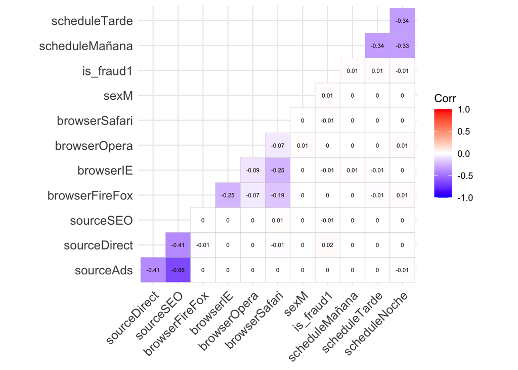

```r
# Corrplot 1
data_fact1 <- data_fact %>% select(source,browser,sex,is_fraud,schedule)
model.matrix(~0+., data=data_fact1) %>%
   cor(use="pairwise.complete.obs") %>%
   ggcorrplot::ggcorrplot(show.diag = F, type="lower", lab=TRUE, lab_size=2)
```

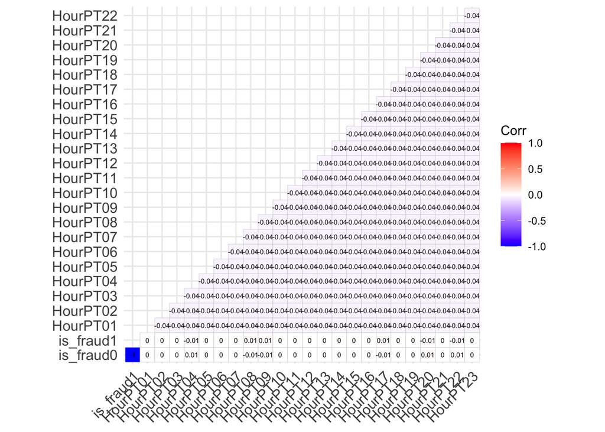

```r
# Corrplot 2
data_fact2 <- data_fact %>% select(is_fraud,HourPT)
model.matrix(~0+., data=data_fact2) %>%
  cor(use="pairwise.complete.obs") %>%
  ggcorrplot::ggcorrplot(show.diag = F, type="lower", lab=TRUE, lab_size=2)
```

Al ver estas tablas de correlación, podemos ver que las variables en general no presentan una correlación significativa entre ellas. En cierta forma esto es bueno ya que nos indica que no hay multicolinealidad.